# Exercise 11

Hubert Rehrauer

27 11 2017

## Requirements

We will use the packages “MLSeq”" and “MLInterfaces”. Please install both.

```r
# source("https://bioconductor.org/biocLite.R")
# biocLite("MLInterfaces")
library(MLInterfaces)
# biocLite("MLSeq")
library(MLSeq)
```

## Load the micro-RNA expression data

The package MLSeq has some micro-RNA expression data from normal (N) and tumor samples (T). These can be loaded with

```r
cervicalFile = system.file("extdata/cervical.txt", package = "MLSeq", mustWork = TRUE)
cervicalCounts_all = as.matrix(read.table(cervicalFile, header = TRUE))
head(cervicalCounts_all)
```

```
##          N1   N2   N3    N4   N5  N6 N7   N8   N9   N10  N11   N12   N13
## let-7a  865  810 5505  6692 1456 588  9 4513 1962 10167 4113  2610  5008
## let-7a*   3   12   30    73    6   2  0  199   10   173   30   105    71
## let-7b  975 2790 4912 24286 1759 508 33 6162 1455 18110 8862 12481 21641
## let-7b*  15   18   27   119   11   3  0  116   17   233   40   180   288
## let-7c  828 1251 2973  6413  713 339 23 2002  476  3294 5929  1816  3278
## let-7c*   0    0    0     1    0   0  0    3    0     3    0     0     3
##          N14 N15   N16   N17   N18   N19   N20   N21   N22  N23  N24  N25
## let-7a   580 667  6731  3671  3276  4910  5876  3877  7516 4930 3755  267
## let-7a*   21   7   738  1051   476   568   643   175   767   48   76    3
## let-7b  8320 918 43582 33730 40209 80226 55768 31744 71032 5486 6932 1162
## let-7b*   63  12   468   479   396   470   686   129   673   65   83   18
## let-7c   573 303  4670  2203  3096  5162  4537  3217  5675 1411 3477  371
## let-7c*    0   0    20     2     6     1    18     6    11    1    5    1
##           N26   N27  N28 N29   T1    T2   T3   T4   T5  T6   T7  T8   T9
## let-7a  56824 16115 5293  38 3343  4990 5193 1464 5342 434 1502  34 2390
## let-7a*   237   103  100  14   12    99   15   12   32   0   18   4   19
## let-7b  59593 15126 5949 103 4217 41617 5152 2536 4551 980 3398 102 2220
## let-7b*   430   155   64 194    8   148   14    8   29   5    5   2   16
## let-7c  37225 10206 2966  25  519  4664 1274  297  673 749  168  28  584
## let-7c*     4     0    0   0    0     3    0    0    0   0    0   0    0
##          T10 T11   T12  T13    T14  T15 T16  T17 T18   T19 T20    T21 T22
## let-7a  3996 687  1780 1030   3459 2520 314 1512 447  2744  37   3174 116
## let-7a*   22   1    58   18    732   88  42   98   5   184   0    648   4
## let-7b  5404 995 12729 3030 108332 6996 938 5685 654 15489  99 102358 184
## let-7b*   24   3    54    4    308   49  12   51   8   106   0    334   1
## let-7c  4118 999  2210 1697   5775 2839 130  762 157   974  34   1711  22
## let-7c*    0   0     3    0      8    2   0    0   0     1   0      4   0
##           T23 T24   T25   T26   T27 T28  T29
## let-7a   1722  68 12121 14398 39196 198 1422
## let-7a*   212   6     2    80   164  18    1
## let-7b  28274 401 14471 24097 73139 669 2492
## let-7b*   189   5    34   115   230   4   15
## let-7c   3127 199  3186  1454  5883 167  321
## let-7c*     2   0     0     1     1   0    0
```

The true class for each sample is given by

```r
cervicalClass = factor(substr(colnames(cervicalCounts_all), 1,1))
head(cervicalClass)
```

```
## [1] N N N N N N
## Levels: N T
```

## Normalization

Use edgeR’s TMM normalization to normalize the counts. Use the log-transformed counts-per-million values with a `prior.count=10`.

```r
library(edgeR)
# From edgeR vigniette:
# The calcNormFactors function normalizes for RNA composition by finding a set of scaling factors for the library sizes that minimize the log-fold changes between the samples for most genes
calcNormFactors(cervicalCounts_all,method = "TMM") #TMM is the default method.
```

```
##  [1] 1.3492228 1.3600643 1.1155620 0.7146882 1.1199952 1.5595557 3.0332545
##  [8] 0.8636173 0.9565616 0.8354871 0.9079170 0.6789921 0.6236301 0.2200584
## [15] 1.7317110 0.4737601 0.4349639 0.5011852 0.6269754 0.5677485 0.5666970
## [22] 0.4941779 1.0924590 0.8717595 1.9099178 0.6112154 0.7663911 0.9839470
## [29] 2.4419851 1.0063767 0.6108430 0.9174155 1.5321313 0.9571516 1.3980836
## [36] 1.1188851 2.9017557 0.9018610 1.0071328 1.4302647 0.6838308 1.4720774
## [43] 1.0053564 1.5278750 1.8602752 0.8780199 1.3172179 0.8512075 3.0296628
## [50] 0.7663000 1.6373490 0.9714768 1.5175450 0.8403271 0.6986701 0.6374418
## [57] 1.6039092 1.3028744
```

```r
# aveLogCPM: This function uses mglmOneGroup to compute average counts-per-million (AveCPM) for each row of counts, and returns log2(AveCPM)
aveLogCPM(cervicalCounts_all, prior.count = 10)
```

[output not shown]

[output cut: 87 more lines]

## Visualization

Create an MDS plot to get an idea of the separability of the samples.

```r
par(mfrow = c(1,2),oma = c(2,0,0,0))
plotMDS(cervicalCounts_all,dim.plot = c(1,2),col = as.numeric(as.factor(cervicalClass)))
```

```
## Found more than one class "MDS" in cache; using the first, from namespace 'dimRed'
```

```
## Also defined by 'limma'
```

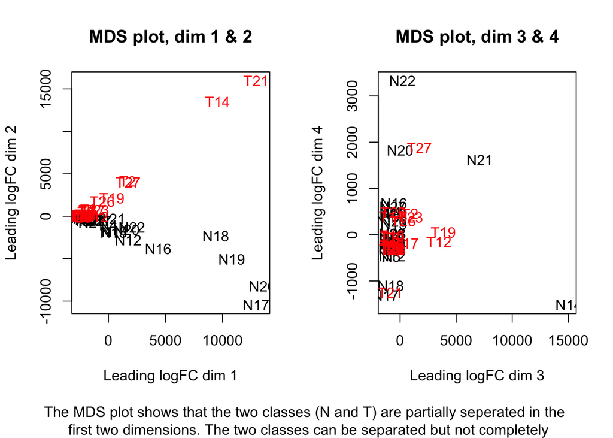

```r
title(main = "MDS plot, dim 1 & 2")
plotMDS(cervicalCounts_all,dim.plot = c(3,4),col = as.numeric(as.factor(cervicalClass)))
title(main = "MDS plot, dim 3 & 4")
mtext("The MDS plot shows that the two classes (N and T) are partially seperated in the \n first two dimensions. The two classes can be separated but not completely",side = 1, line = 1,outer = TRUE)
```

## Nonspecific filtering

In order to reduce the dimensionality, Use only those micro-RNAs where the row variance is larger then 0.5.

```r
#Row variance
Rowvar <- apply(cervicalCounts_all,1,var)
cervicalCounts <- cervicalCounts_all[Rowvar > 0.5,]
paste("Original matrix has",nrow(cervicalCounts),"of which", nrow(cervicalCounts_all), "have a row variance larger than 0.5")
```

[output not shown]

## k-nn classification

Implement a k-nn classification with cross-validation use the function `knn.cv` from the package `class`.

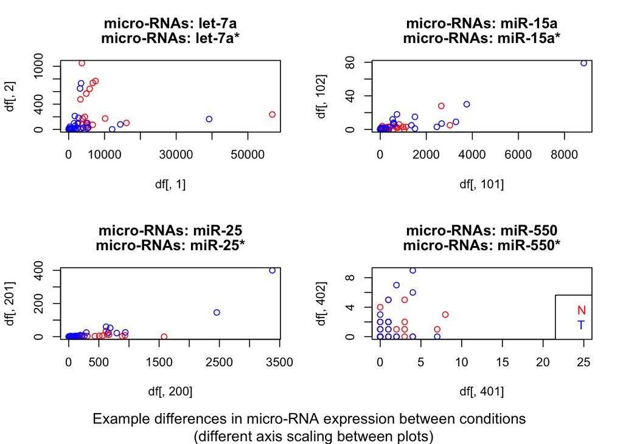

```r
# install.packages("class")
library(class)

# classes:
class = data.frame(condition = factor(rep(c(0, 1), c(29, 29)))) #29

data <- t(cervicalCounts)
df  <- cbind(data, class)

par(mfrow = c(2,2),oma = c(2,0,0,0))
plot(df[,1], df[,2],
     main=paste("micro-RNAs:",colnames(df)[c(1,2)]),
     col=ifelse(as.character(df[,ncol(df)])==0, "red","blue"))
plot(df[,101], df[,102],
     main=paste("micro-RNAs:",colnames(df)[c(101,102)]),
     col=ifelse(as.character(df[,ncol(df)])==0, "red","blue"))
plot(df[,200], df[,201],
     main=paste("micro-RNAs:",colnames(df)[c(200,201)]),
     col=ifelse(as.character(df[,ncol(df)])==0, "red","blue"))
plot(df[,401], df[,402],
    main=paste("micro-RNAs:",colnames(df)[c(401,402)]),
     col=ifelse(as.character(df[,ncol(df)])==0, "red","blue"))
legend("bottomright", legend=c("N","T"),
    text.col=c("red","blue"), bty="o")
mtext("Example differences in micro-RNA expression between conditions \n (different axis scaling between plots)",side = 1, line = 1,outer = TRUE)
```

#### Computing the f1-score (or f-score or f-measure)

```r
# The formula is:
# Fscore = (2*Precision*Recall) / sum(Precision, Recall)
# with:
# precision = TP / (TP + FP)
# recall    = TP / (TP + FN)

#I was not able to extract the false and true positive and the false negative value from the knn classification.

# On stackexchange I could find this and a helpful package, however I was not able to compute a F1 score.
# https://stackoverflow.com/questions/8499361/easy-way-of-counting-precision-recall-and-f1-score-in-r
#install.packages("ROCR")
library(ROCR)
```

```r
#the performance function yields a recall precision curve and a vector of F1 scores.
```

[output not shown]

## MLInterfaces

Implement the same scheme using the MLInterfaces package., and using knn.cv’s internal cross-valdiation scheme. For that the data needs to be casted in a variable of class `ExpressionSet`

```r
c <- data.frame(classification = cervicalClass)
rownames(c) <- colnames(cervicalCounts)
c_annotated <- AnnotatedDataFrame(c)

cervES = new("ExpressionSet", exprs=cervicalCounts, phenoData=c_annotated)
```

The k-nn classifier with cross-validation is now implemented as:

```r
knn1 = MLearn(classification~., cervES, knn.cvI(k=5), trainInd=1:ncol(cervES))
confuMat(knn1)
```

[output not shown]

Setup a balanced k-fold cross-validation scheme

```r
k = 10
knnCv = MLearn(classification~., cervES, knnI(k=5), xvalSpec("LOG", k, balKfold.xvspec(k)))
confuMat(knnCv)
```

[output not shown]

The confusion matrix compares the true classification with the predicted classification and yields an overview of the performance of the used algorithm and parameters.

## Other classifiers

Compute the performance of the diagonal linear discriminant analysis and support vector machines provided by MLInterfaces.

```r
# I am not sure how to answer this question. I run a code below that uses svm and random forest to classify the cervical dataset.
```

## Other classifiers and additional code

The bioconductor website offered a very interesting example on the knn.cv function plus different ML techniques that are used here and run in a modified version below: https://www.bioconductor.org/help/course-materials/2014/SeattleOct2014/B02.3_MachineLearning.html

```r
#Split the data into test and training datasets:

set.seed(9) #Set seed is set in order to keep the sampling for splitting the dataset reproducible between runs.
nTest = ceiling(ncol(cervicalCounts) * 0.2)
ind = sample(ncol(cervicalCounts), nTest, FALSE) #take randomly 20% of rows / features

#Training data: 80%
cervicalCounts.train = cervicalCounts[, -ind]
cervicalCounts.train = as.matrix(cervicalCounts.train + 1) #to every value +1 is added.
class_train = data.frame(condition = class[-ind, ]) # also take the corresponding class labels

#Testing data: 20%
cervicalCounts.test = cervicalCounts[, ind]
cervicalCounts.test = as.matrix(cervicalCounts.test + 1) #to every value +1 is added.
class_test = data.frame(condition = class[ind, ]) # also take the corresponding class labels
```

```r
newknn <- function( testset, trainset, testclass, trainclass, k) #function used from the bioconductor website
{
    pred.train <- knn.cv(trainset, trainclass, k=k)
    pred.test <- knn(trainset, testset, trainclass, k=k)

    test_fit <- length(which(mapply(identical, as.character(pred.test),
        testclass)==FALSE))/length(testclass)

    train_fit <- length(which(mapply(identical, as.character(pred.train),
            trainclass)==FALSE))/length(trainclass)

    c(train_fit=train_fit, test_fit= test_fit)
}

trainset <- t(cervicalCounts.train)
testset <- t(cervicalCounts.test)
testclass <- t(class_test)
trainclass <- t(class_train)
klist <- 1:40 # number of neighbors
```

```r
ans <- lapply(klist, function(x) newknn(testset, trainset, testclass, trainclass,k =x)) #running the function for different numbers of neigbors
resdf <- t(as.data.frame(ans))
rownames(resdf) <- NULL
```

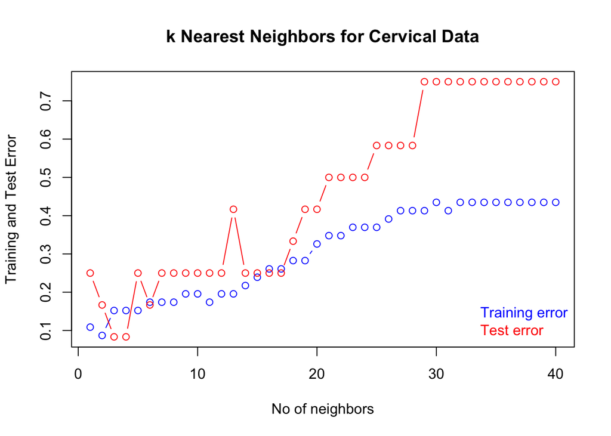

```r
plot(klist, resdf[,"train_fit"], col="blue", type="b",ylim=c(range(resdf)),
    main="k Nearest Neighbors for Cervical Data", xlab="No of neighbors",
    ylab ="Training and Test Error")
points(klist, resdf[,"test_fit"], col="red", type="b")
legend("bottomright", legend=c("Training error","Test error"),
    text.col=c("blue","red"), bty="n")
```

This plot illustrates how the quality of the classification (training and test error) changes depending on the number of neighbors that are used. We can observe that lower number of neighbors should be preferred.

## Using random forest to predict class labels for cervical data:

```r
# Training data
cerv_trained = DESeqDataSetFromMatrix(countData = cervicalCounts.train,
        colData = class_train, formula(~condition))
cerv_trained = DESeq(cerv_trained, fitType = "local")
```

```
## -- replacing outliers and refitting for 66 genes
## -- DESeq argument 'minReplicatesForReplace' = 7
## -- original counts are preserved in counts(dds)
```

```r
# Testing data
cerv_test = DESeqDataSetFromMatrix(countData = cervicalCounts.test, colData = class_test,
formula(~condition))
cerv_test = DESeq(cerv_test, fitType = "local")
```

```
## -- replacing outliers and refitting for 37 genes
## -- DESeq argument 'minReplicatesForReplace' = 7
## -- original counts are preserved in counts(dds)
```

```r
# install.packages("e1071")
library(e1071)
rf = classify(data = cerv_trained, method = "randomforest", normalize = "deseq",
deseqTransform = "vst", cv = 5, rpt = 3, ref = "1")
```

```
## found already estimated dispersions, replacing these
```

```r
# Display information about the trained model and its performance
trained(rf)
```

```
## Random Forest
##
##  46 samples
## 582 predictors
##   2 classes: '1', '0'
##
## No pre-processing
## Resampling: Cross-Validated (5 fold, repeated 3 times)
## Summary of sample sizes: 37, 37, 36, 37, 37, 37, ...
## Resampling results across tuning parameters:
##
##   mtry  Accuracy   Kappa
##     2   0.8459259  0.6691498
##    34   0.8903704  0.7699883
##   581   0.8762963  0.7409097
##
## Accuracy was used to select the optimal model using  the largest value.
## The final value used for the model was mtry = 34.
```

```r
# Confusion matrix: comparing predicted to the true class labels
pred.rf = predictClassify(rf, cerv_test)
```

```
## found already estimated dispersions, replacing these
```

```r
table(pred.rf, relevel(cerv_test$condition, 2))
```

```
##
## pred.rf 1 0
##       1 3 0
##       0 0 9
```

The trained model using random forest performs very well.

A model can also be trained using svm, however, the performance is lower:

```r
rf = classify(data = cerv_trained, method = "svm", normalize = "deseq",
deseqTransform = "vst", cv = 5, rpt = 3, ref = "1")
```

```
## found already estimated dispersions, replacing these
```

```r
pred.rf = predictClassify(rf, cerv_test)
```

```
## found already estimated dispersions, replacing these
```

```r
table(pred.rf, relevel(cerv_test$condition, 2))
```

```
##
## pred.rf 1 0
##       1 3 9
##       0 0 0
```